# Lab 8: Data Frame Functions and Simulation Exploration

Author

Aiden Rodriguez

```r
library(tidyverse)
library(knitr)
```

```r
fish = read_csv("BlackfootFish.csv")
```

### Standardizing Variables

```r
fish <- fish |>
  mutate(length = (length - min(length, na.rm = TRUE)) /
           (max(length, na.rm = TRUE) - min(length, na.rm = TRUE)),
         weight = (weight - min(weight, na.rm = TRUE)) /
           (max(weight, na.rm = TRUE) - min(length, na.rm = TRUE)))
```

**1. What is the mistake I made in the above rescaling code?**

The first one does max length - min length, however the second weight based one does max weight - min length. It should both be weight here and was a copy paste error that was pretty easy to overlook.

**2. Start by writing a function that rescales a vector. Transform the repeated process above into a `rescale_01()` function. Your function should…**

```r
rescale_01 <- function(x) {
  rng <- range(x, na.rm = TRUE)
  (x - rng[1]) / (rng[2] - rng[1])
}
```

**3. Run the code below to test your function. Verify that the maximum of your rescaled vector is 1 and the minimum is 0!**

```r
rescaled <- rescale_01(fish$weight)

min(rescaled, na.rm = TRUE)
```

```
[1] 0
```

```r
max(rescaled, na.rm = TRUE)
```

```
[1] 1
```

**4. Create a `rescale_column()` function that accepts two arguments:**

```r
rescale_column <- function(df, cols) {
  df |>
    mutate(
      across({{ cols }}, rescale_01)
    )
}
```

**5. Run the code below to test your function. You might need to edit the code if you call your dataset something different.**

```r
fish |>
  rescale_column(c(length, weight)) |>
  select(length:weight) |>
  slice_head(n = 5) |>
  kable()
```

| length | weight |
| --- | --- |
| 0.2804124 | 0.0374171 |
| 0.2804124 | 0.0406243 |
| 0.2773196 | 0.0523840 |
| 0.3154639 | 0.0587984 |
| 0.3051546 | 0.0641437 |

### Accounting for Unlikely Values

**6. Write a function that will replace unlikely values of a variable in a dataframe with missing values. Your function should accept at least four inputs**:

```r
clean_values <- function(df, col, min_val, max_val) {
  df |>
    mutate(
      {{ col }} := if_else(
        {{ col }} < min_val | {{ col }} > max_val,
        NA,
        {{ col }}
      )
    )
}
```

**7. Write a test that demonstrates that your function worked using the fish data!**

```r
clean_values(fish, length, 100, 300)
```

```
# A tibble: 18,352 × 7
    trip  mark length weight  year section  species
   <dbl> <dbl>  <dbl>  <dbl> <dbl> <chr>    <chr>
 1     1     0    288    175  1989 Johnsrud RBT
 2     1     0    288    190  1989 Johnsrud RBT
 3     1     0    285    245  1989 Johnsrud RBT
 4     1     0     NA    275  1989 Johnsrud RBT
 5     1     0     NA    300  1989 Johnsrud RBT
 6     1     0     NA    380  1989 Johnsrud RBT
 7     1     0    269    170  1989 Johnsrud RBT
 8     1     0    160     40  1989 Johnsrud RBT
 9     1     0    213     80  1989 Johnsrud RBT
10     1     0    157     35  1989 Johnsrud RBT
# ℹ 18,342 more rows
```

```r
# Here I just use 300 as a value to show that it will remove some max values.
# But it seems like the actual reasonable limit is something like 400.
```

## Random Babies Simulation

**8. Simulate the distribution of the number of babies that are correctly returned if there were four babies born in a night at our disorganized hospital. Use 10,000 simulations. Make sure to add a line of code to make your simulation reproducible every time you run it.**

```r
randomBabies <- function(babies){

  correct_order <- 1:babies
  returned_order <- sample(1:babies)
  sum(correct_order == returned_order)

}
```

```r
results <- map_int(
  .x = 1:10000,
  .f = ~ randomBabies(4)
)
```

**9. Create a table displaying the proportion of simulations where 0, 1, 2, 3, and 4 babies were given to their correct parent(s).**

```r
raw_df <- enframe(results, value = "matches")

proportions <- raw_df |>
  count(matches) |>
  mutate(proportion = n / sum(n))

kable(proportions)
```

| matches | n | proportion |
| --- | --- | --- |
| 0 | 3738 | 0.3738 |
| 1 | 3343 | 0.3343 |
| 2 | 2473 | 0.2473 |
| 4 | 446 | 0.0446 |

**10. Now create a barplot showing the proportion of simulations where 0, 1, 2, 3, and 4 babies were given to their correct parent(s).** Don’t forget a title and appropriate axis labels.

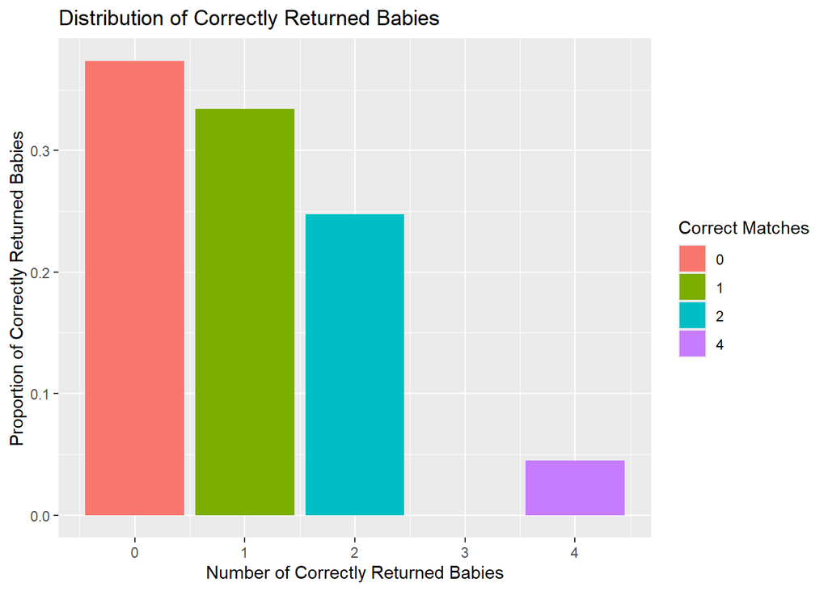

```r
ggplot(proportions, aes(x = matches,
                        y = proportion,
                        fill = factor(matches))) +
  geom_col() +
  labs(
    title = "Distribution of Correctly Returned Babies",
    x = "Number of Correctly Returned Babies",
    y = "Proportion of Correctly Returned Babies",
    fill = "Correct Matches"
  )
```